# Offshore Blue Crab Densities for The Gulf of Mexico

Adam A Kemberling

1/4/2020

# Data Set Summary

- Total Number of Stations = 10451
- Starting in 2000 and continuing through 2018
- Total Sapidus Caught was 5531
- Overall Frequency of Occurrence was 16.1228591

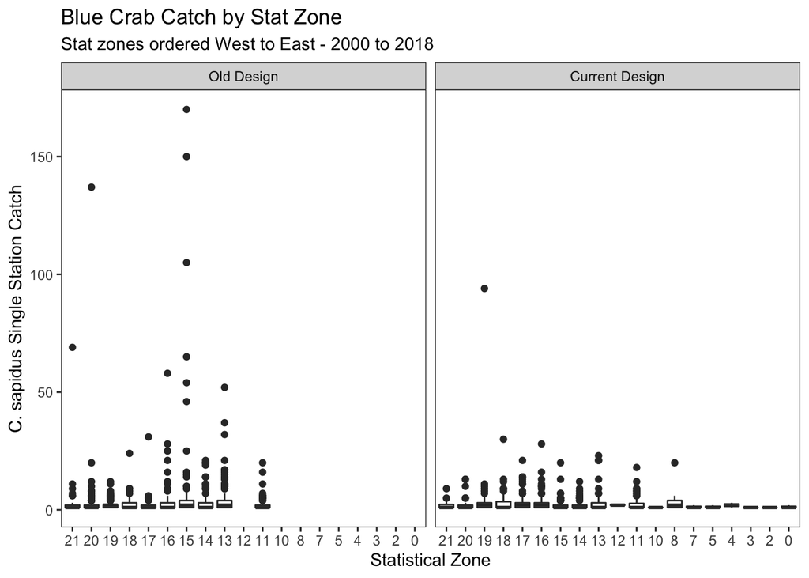

# Factor Summaries

## Yearly Summaries

**Overall Mean Catch Crabs/Hectare:** 0.199

**Stations with no catch:** 8766 / 10451 Stations **or** 83.88%

| Survey_Year | Stations | Missing Obs | % Occurrence | Mean Catch | SD | Overdispersed |
| --- | --- | --- | --- | --- | --- | --- |
| 2000 | 497 | 0 | 0.1247485 | 0.1430723 | 0.7418709 | yes |
| 2001 | 423 | 0 | 0.1560284 | 0.3999519 | 2.5068184 | yes |
| 2002 | 516 | 0 | 0.2151163 | 0.3052766 | 1.4236905 | yes |
| 2003 | 486 | 0 | 0.2098765 | 0.3210508 | 1.2982149 | yes |
| 2004 | 445 | 0 | 0.1842697 | 0.2669802 | 1.1315465 | yes |
| 2005 | 431 | 0 | 0.3039443 | 0.7309055 | 4.4504559 | yes |
| 2006 | 398 | 0 | 0.2512563 | 0.2974087 | 1.2510404 | yes |
| 2007 | 403 | 0 | 0.2431762 | 0.3695068 | 2.1259831 | yes |
| 2008 | 598 | 0 | 0.1505017 | 0.0887166 | 0.2906761 | no |
| 2009 | 983 | 0 | 0.1576806 | 0.1372921 | 0.5387720 | yes |
| 2010 | 700 | 0 | 0.1571429 | 0.1408543 | 0.5082154 | yes |
| 2011 | 549 | 0 | 0.2021858 | 0.2321763 | 0.8469300 | yes |
| 2012 | 589 | 0 | 0.0916808 | 0.0595966 | 0.2344135 | no |
| 2013 | 506 | 0 | 0.0790514 | 0.0494838 | 0.2574674 | yes |
| 2014 | 685 | 0 | 0.1138686 | 0.1251746 | 1.2178975 | yes |
| 2015 | 700 | 0 | 0.1314286 | 0.1177831 | 0.5375021 | yes |
| 2016 | 548 | 0 | 0.1423358 | 0.1173202 | 0.4557866 | yes |
| 2017 | 603 | 0 | 0.1293532 | 0.1521905 | 0.6661890 | yes |
| 2018 | 391 | 0 | 0.1202046 | 0.0789907 | 0.3358133 | yes |

### Yearly Catch Plot

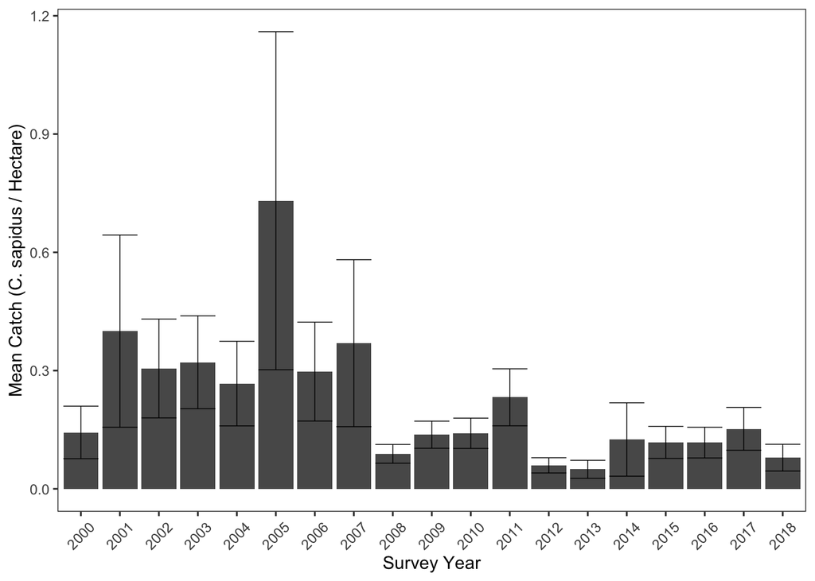

### Yearly Frequency of Occurrence

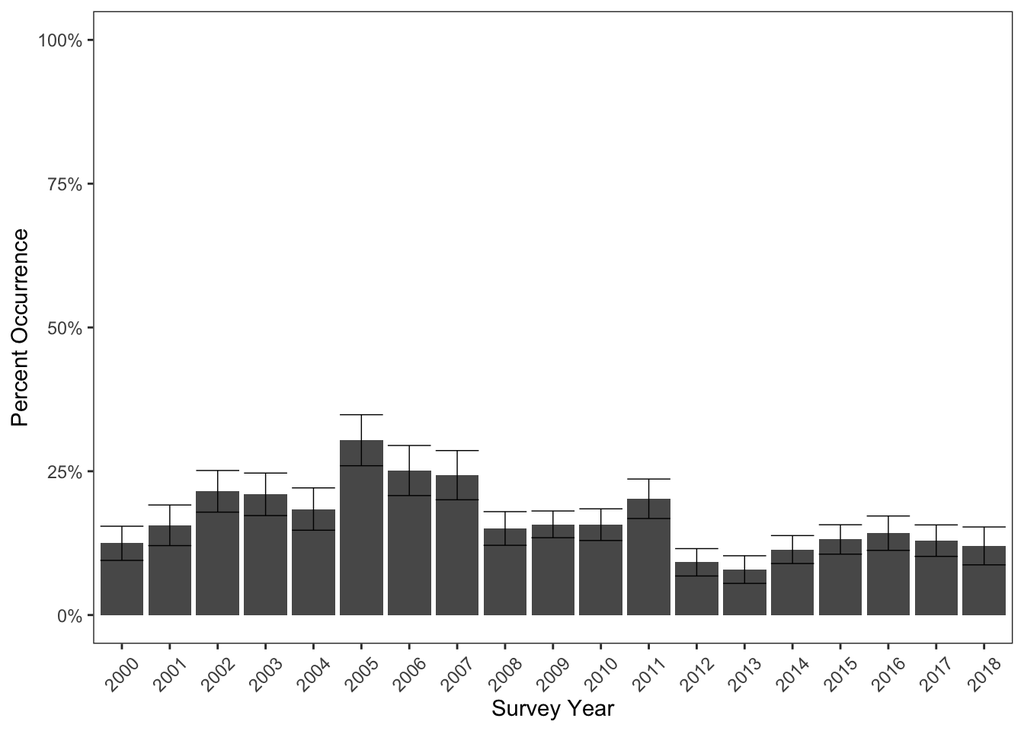

### Yearly Side-by

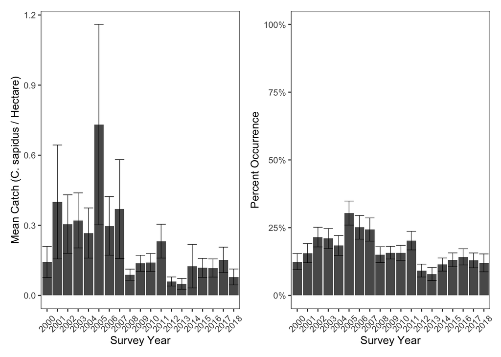

## Stat Zone Summaries

| StatZone | Stations | Missing Obs | % Occurrence | Mean Catch | SD | Overdispersed |
| --- | --- | --- | --- | --- | --- | --- |
| 1 | 5 | 0 | 0.0000000 | 0.0000000 | 0.0000000 | no |
| 2 | 125 | 0 | 0.0160000 | 0.0047240 | 0.0371959 | no |
| 3 | 399 | 0 | 0.0100251 | 0.0028436 | 0.0283030 | no |
| 4 | 443 | 0 | 0.0067720 | 0.0037170 | 0.0492515 | no |
| 5 | 416 | 0 | 0.0072115 | 0.0026857 | 0.0333903 | no |
| 6 | 415 | 0 | 0.0000000 | 0.0000000 | 0.0000000 | no |
| 7 | 253 | 0 | 0.0118577 | 0.0044019 | 0.0423148 | no |
| 8 | 281 | 0 | 0.0533808 | 0.0596740 | 0.3968039 | yes |
| 9 | 199 | 0 | 0.0000000 | 0.0000000 | 0.0000000 | no |
| 10 | 190 | 0 | 0.0421053 | 0.0143626 | 0.0695699 | no |
| 11 | 1106 | 0 | 0.1672694 | 0.1723934 | 0.8055450 | yes |
| 12 | 55 | 0 | 0.1454545 | 0.1419970 | 0.4399969 | yes |
| 13 | 396 | 0 | 0.4065657 | 0.9149865 | 2.7089809 | yes |
| 14 | 724 | 0 | 0.2997238 | 0.3343395 | 1.1222703 | yes |
| 15 | 732 | 0 | 0.2786885 | 0.5402363 | 3.5939280 | yes |
| 16 | 810 | 0 | 0.2197531 | 0.2461144 | 1.1254532 | yes |
| 17 | 914 | 0 | 0.1991247 | 0.1726239 | 0.5750543 | yes |
| 18 | 769 | 0 | 0.2028609 | 0.1800542 | 0.6481025 | yes |
| 19 | 772 | 0 | 0.2059585 | 0.1991595 | 1.2096515 | yes |
| 20 | 783 | 0 | 0.1558110 | 0.1569738 | 1.2266493 | yes |
| 21 | 663 | 0 | 0.1131222 | 0.1336667 | 1.0744834 | yes |

### Stat Zone Catch Plot

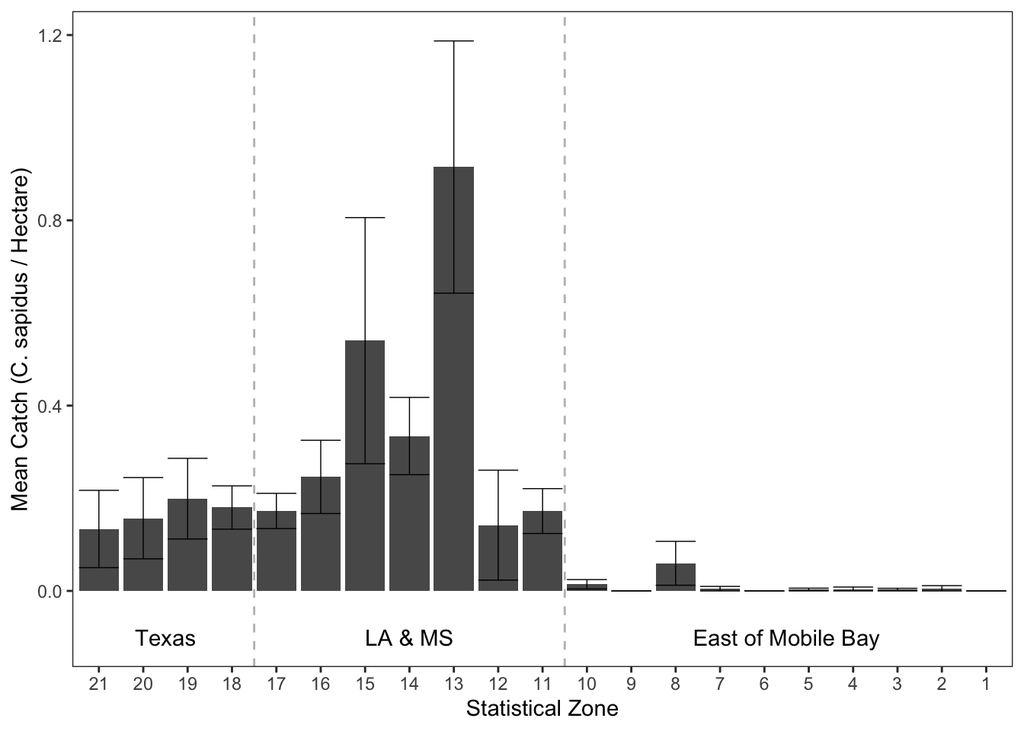

### Stat Zone Frequency of Occurrence

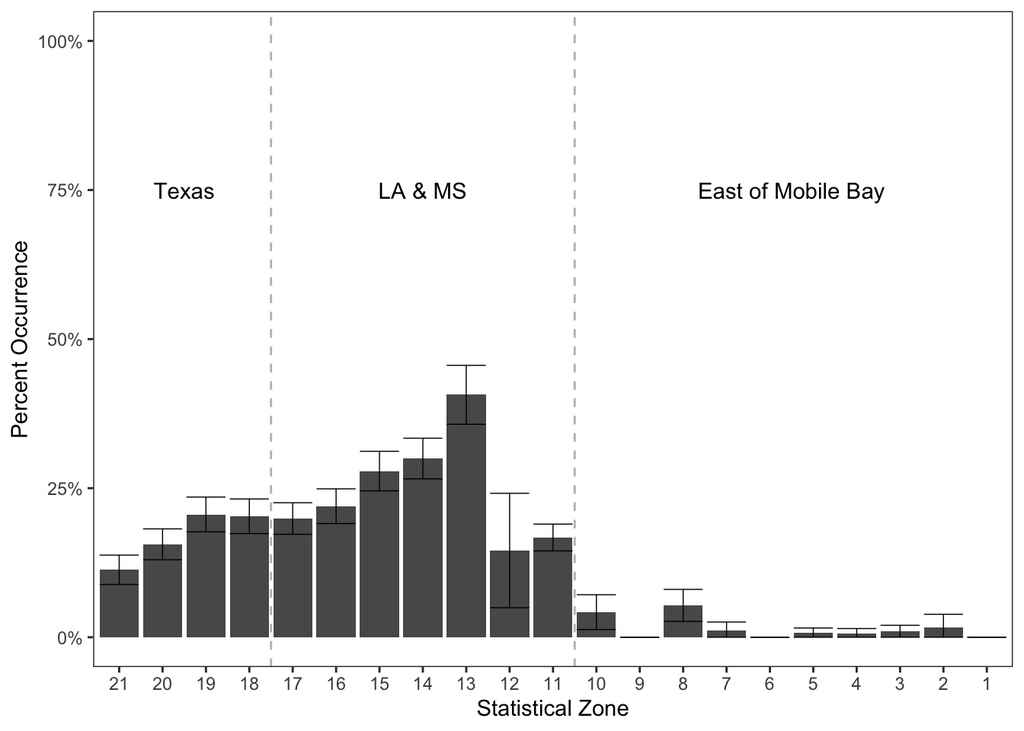

### Stat Zone Side-by

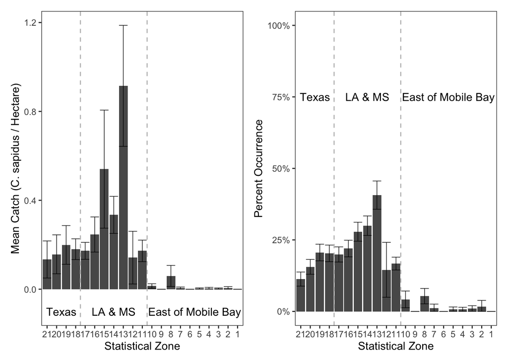

## Region Summary

| region | Stations | Missing Obs | % Occurrence | Mean Catch | SD | Overdispersed |
| --- | --- | --- | --- | --- | --- | --- |
| Texas | 2987 | 0 | 0.1714094 | 0.1686456 | 1.0660434 | yes |
| Louisiana | 3577 | 0 | 0.2633492 | 0.3793627 | 2.0320024 | yes |
| MS Bight | 1351 | 0 | 0.1487787 | 0.1489310 | 0.7365881 | yes |
| Florida | 2536 | 0 | 0.0118297 | 0.0088214 | 0.1367223 | yes |

### Regional Catch Plot

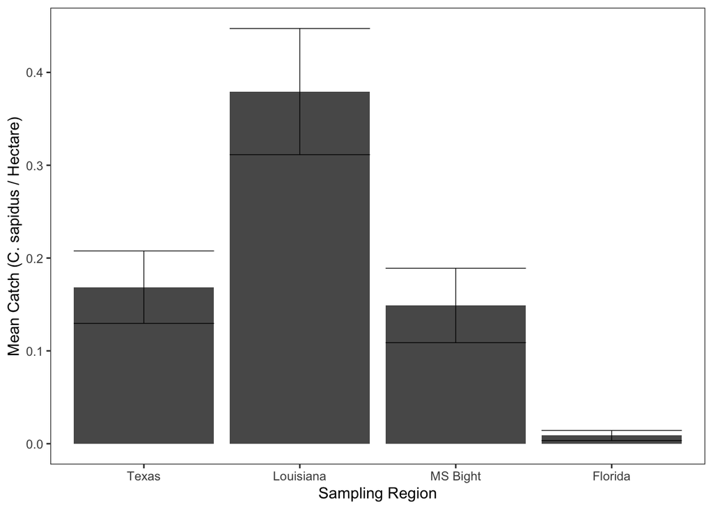

### Regional Frequency of Occurrence

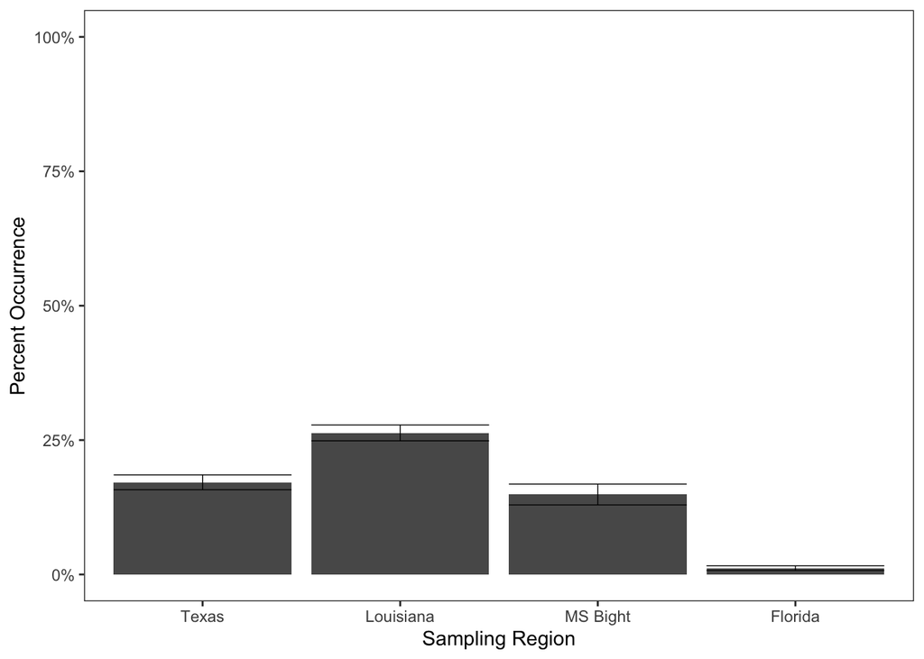

### Regional Side-by

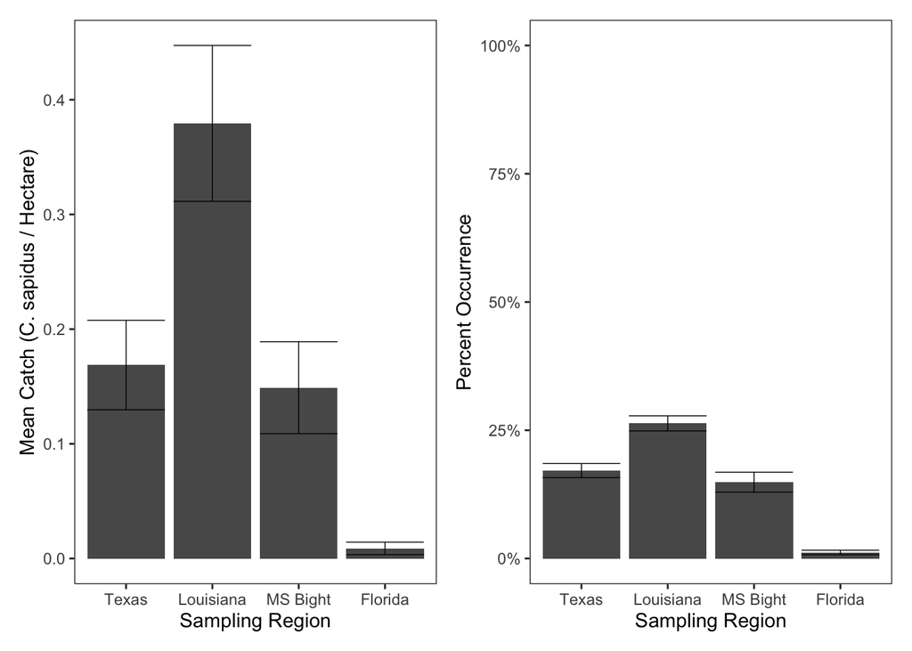

## Region - Season

| region | Season | Stations | Missing Obs | % Occurrence | Mean Catch | SD | Overdispersed |
| --- | --- | --- | --- | --- | --- | --- | --- |
| Texas | Summer | 1559 | 0 | 0.2373316 | 0.2236771 | 0.9768701 | yes |
| Texas | Fall | 1428 | 0 | 0.0994398 | 0.1085657 | 1.1529185 | yes |
| Louisiana | Summer | 1855 | 0 | 0.3347709 | 0.5529719 | 2.6690359 | yes |
| Louisiana | Fall | 1722 | 0 | 0.1864111 | 0.1923446 | 0.9153126 | yes |
| MS Bight | Summer | 695 | 0 | 0.1899281 | 0.2180501 | 0.9777604 | yes |
| MS Bight | Fall | 656 | 0 | 0.1051829 | 0.0757027 | 0.3080248 | yes |
| Florida | Summer | 1570 | 0 | 0.0159236 | 0.0133319 | 0.1728732 | yes |
| Florida | Fall | 966 | 0 | 0.0051760 | 0.0014906 | 0.0206892 | no |

### Region - Season Catch

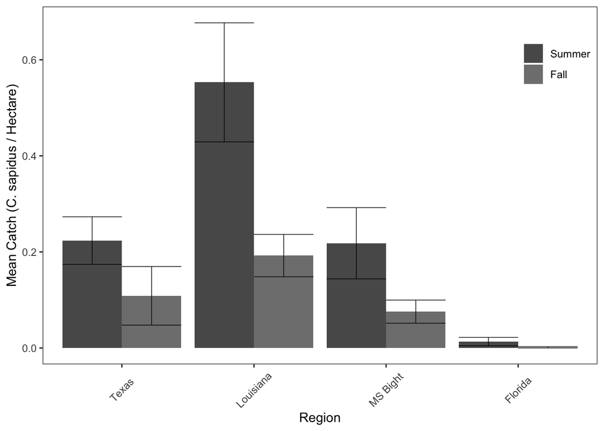

### Region - Season FOO

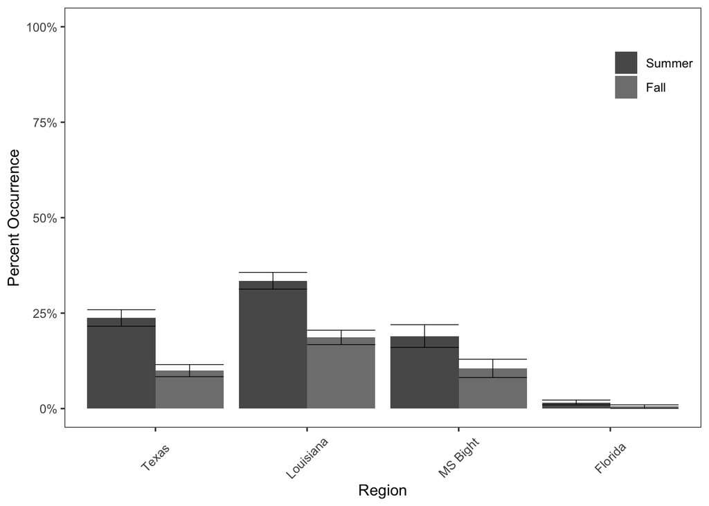

### Region - Season Side-by

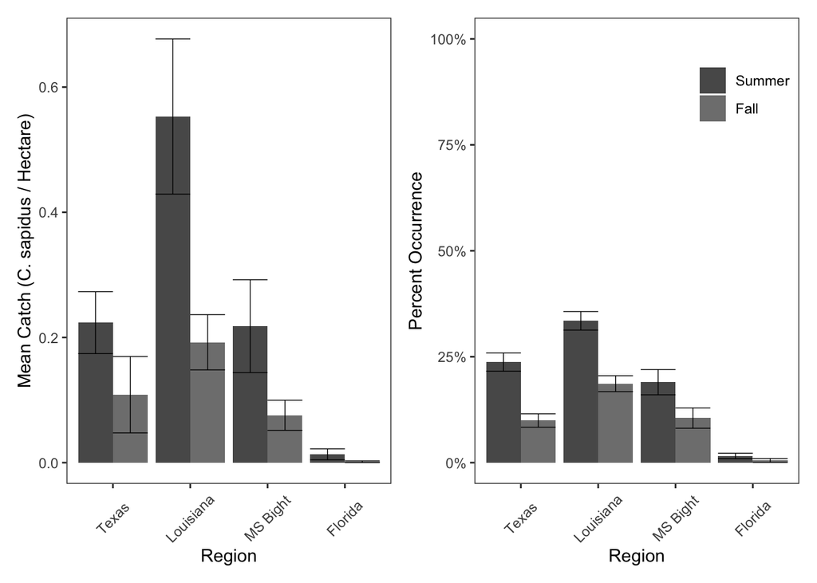

## Seasonal Summary

| Survey_Year | Season | Stations | Missing Obs | % Occurrence | Mean Catch | SD | Overdispersed |
| --- | --- | --- | --- | --- | --- | --- | --- |
| 2000 | Summer | 251 | 0 | 0.1872510 | 0.2421858 | 1.0033596 | yes |
| 2000 | Fall | 246 | 0 | 0.0609756 | 0.0419443 | 0.2580981 | yes |
| 2001 | Summer | 172 | 0 | 0.2383721 | 0.9058880 | 3.8750995 | yes |
| 2001 | Fall | 251 | 0 | 0.0996016 | 0.0532547 | 0.1990548 | no |
| 2002 | Summer | 258 | 0 | 0.2829457 | 0.4726460 | 1.9025609 | yes |
| 2002 | Fall | 258 | 0 | 0.1472868 | 0.1379073 | 0.6210433 | yes |
| 2003 | Summer | 206 | 0 | 0.3543689 | 0.4785203 | 1.2481802 | yes |
| 2003 | Fall | 280 | 0 | 0.1035714 | 0.2051983 | 1.3240994 | yes |
| 2004 | Summer | 252 | 0 | 0.2301587 | 0.3461199 | 1.3364643 | yes |
| 2004 | Fall | 193 | 0 | 0.1243523 | 0.1636476 | 0.7790789 | yes |
| 2005 | Summer | 179 | 0 | 0.3240223 | 1.2656170 | 6.6823714 | yes |
| 2005 | Fall | 252 | 0 | 0.2896825 | 0.3510905 | 1.3841155 | yes |
| 2006 | Summer | 235 | 0 | 0.3446809 | 0.4610205 | 1.5999632 | yes |
| 2006 | Fall | 163 | 0 | 0.1165644 | 0.0615268 | 0.2074697 | no |
| 2007 | Summer | 179 | 0 | 0.2793296 | 0.2644754 | 0.7826726 | yes |
| 2007 | Fall | 224 | 0 | 0.2142857 | 0.4534382 | 2.7645823 | yes |
| 2008 | Summer | 288 | 0 | 0.1250000 | 0.0768972 | 0.2739921 | no |
| 2008 | Fall | 310 | 0 | 0.1741935 | 0.0996972 | 0.3053934 | no |
| 2009 | Summer | 539 | 0 | 0.2393321 | 0.2250547 | 0.7041287 | yes |
| 2009 | Fall | 444 | 0 | 0.0585586 | 0.0307515 | 0.1434819 | no |
| 2010 | Summer | 386 | 0 | 0.2020725 | 0.2032538 | 0.6373493 | yes |
| 2010 | Fall | 314 | 0 | 0.1019108 | 0.0641468 | 0.2577660 | yes |
| 2011 | Summer | 329 | 0 | 0.2401216 | 0.2478884 | 0.6765975 | yes |
| 2011 | Fall | 220 | 0 | 0.1454545 | 0.2086794 | 1.0527617 | yes |
| 2012 | Summer | 391 | 0 | 0.1023018 | 0.0670658 | 0.2382140 | no |
| 2012 | Fall | 198 | 0 | 0.0707071 | 0.0448467 | 0.2265906 | yes |
| 2013 | Summer | 313 | 0 | 0.1118211 | 0.0704450 | 0.3082615 | yes |
| 2013 | Fall | 193 | 0 | 0.0259067 | 0.0154898 | 0.1343925 | yes |
| 2014 | Summer | 364 | 0 | 0.1236264 | 0.1727832 | 1.6472389 | yes |
| 2014 | Fall | 321 | 0 | 0.1028037 | 0.0711885 | 0.2949376 | yes |
| 2015 | Summer | 377 | 0 | 0.1803714 | 0.1644393 | 0.5735665 | yes |
| 2015 | Fall | 323 | 0 | 0.0743034 | 0.0633268 | 0.4873321 | yes |
| 2016 | Summer | 354 | 0 | 0.1638418 | 0.1475319 | 0.5221085 | yes |
| 2016 | Fall | 194 | 0 | 0.1030928 | 0.0621916 | 0.2923462 | yes |
| 2017 | Summer | 322 | 0 | 0.1987578 | 0.2661089 | 0.8896509 | yes |
| 2017 | Fall | 281 | 0 | 0.0498221 | 0.0216505 | 0.1216030 | no |
| 2018 | Summer | 284 | 0 | 0.1232394 | 0.0910192 | 0.3813359 | yes |
| 2018 | Fall | 107 | 0 | 0.1121495 | 0.0470648 | 0.1589276 | no |

### Seasonal Catch Plot

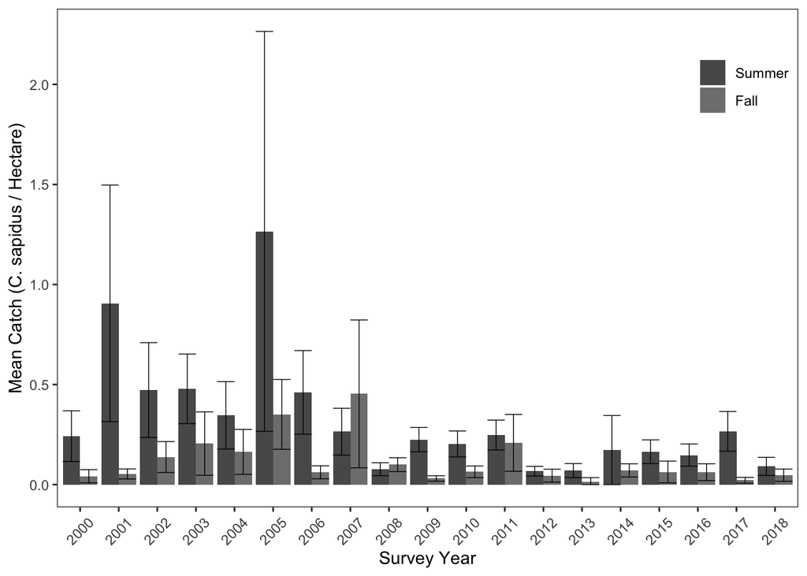

### Seasonal Frequency of Occurrence

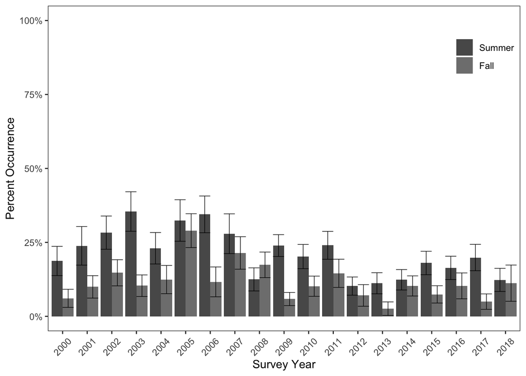

### Seasonal Side-by

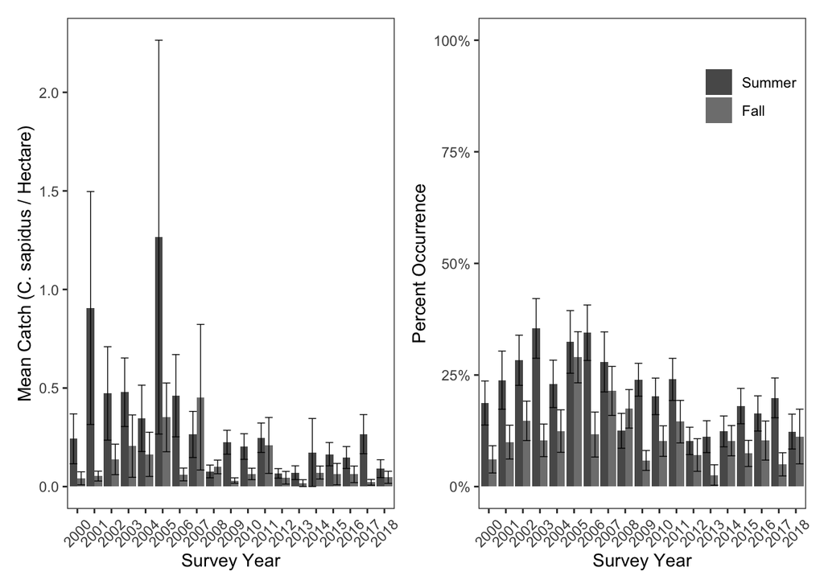

# East-West Models

## Model A. 2000-2018

Model is a generalized linear model with a negative binomial error distribution. Blue crab catch is predicted as the sum of linear predictors for the year and season when the station was sampled in addition to the region in which it took place, with an interaction between survey year and region. An offset of area towed in hectares was used to predict catch as a rate and account for differences in sampling effort at different stations.

### Interaction Plot

Looking at an interaction plot indicates that the impact of each region is not consistent across years and that there is an important interaction in the data.

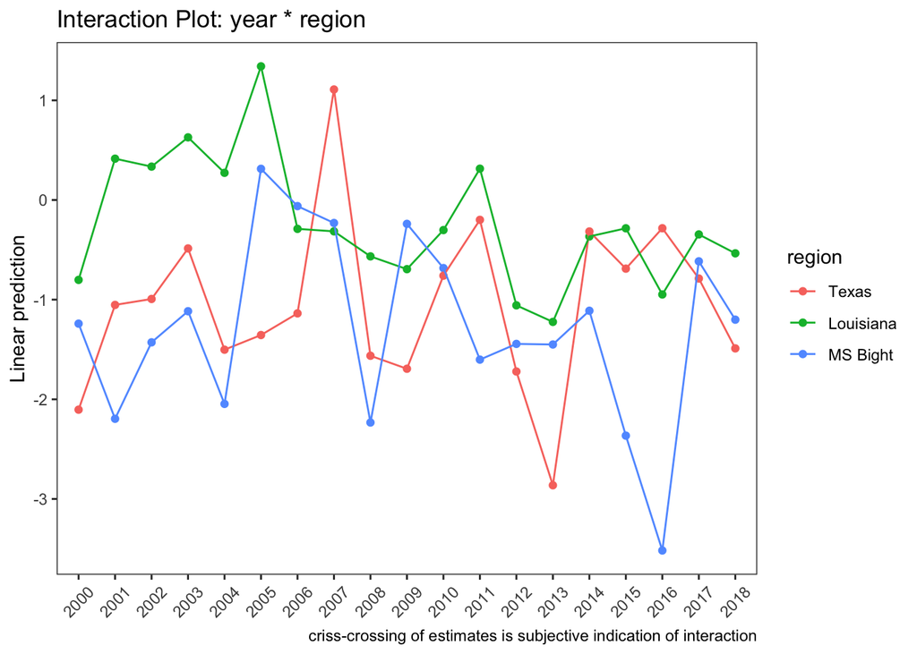

### Model Summary

Understanding p-values in glm model summary. Using the default settings in R sets the contrast levels for factors such that all factors are contrasted against the first/lowest factor level.

For example in our model year is modeled as a factor, which adjusts the intercept for the model for each. The first year is 2000, so all other years are contrasted against that year’s mean estimate. One quick way to confirm what factor level is the contrast is y checking which levels are absent from the summary table `summary(my_model)`

Contrasts:  
year = 2000  
region = texas  
season = summer

P-values on factor levels in these tables indicate significant deviation from the contrasts. Post-hoc tests are necessary to compare individual levels against one another.

| term | estimate | std.error | statistic | p.value | signif. |
| --- | --- | --- | --- | --- | --- |
| (Intercept) | -2.6733145 | 0.2861883 | -9.3411033 | 0.0000000 | * |
| year_f2001 | 1.0514664 | 0.3885198 | 2.7063389 | 0.0068030 | * |
| year_f2002 | 1.1109845 | 0.3641262 | 3.0510975 | 0.0022801 | * |
| year_f2003 | 1.6181556 | 0.3560574 | 4.5446484 | 0.0000055 | * |
| year_f2004 | 0.6019168 | 0.3800132 | 1.5839367 | 0.1132081 |  |
| year_f2005 | 0.7490335 | 0.3767514 | 1.9881373 | 0.0467965 | * |
| year_f2006 | 0.9665631 | 0.3737927 | 2.5858266 | 0.0097146 | * |
| year_f2007 | 3.2133377 | 0.3577372 | 8.9823978 | 0.0000000 | * |
| year_f2008 | 0.5411915 | 0.3862421 | 1.4011717 | 0.1611627 |  |
| year_f2009 | 0.4107633 | 0.3550392 | 1.1569522 | 0.2472919 |  |
| year_f2010 | 1.3448689 | 0.3594471 | 3.7414936 | 0.0001829 | * |
| year_f2011 | 1.9049743 | 0.3591069 | 5.3047558 | 0.0000001 | * |
| year_f2012 | 0.3831549 | 0.4033193 | 0.9500038 | 0.3421103 |  |
| year_f2013 | -0.7583901 | 0.5169107 | -1.4671588 | 0.1423329 |  |
| year_f2014 | 1.7883269 | 0.3715749 | 4.8128305 | 0.0000015 | * |
| year_f2015 | 1.4152758 | 0.3734316 | 3.7899204 | 0.0001507 | * |
| year_f2016 | 1.8209074 | 0.3783259 | 4.8130653 | 0.0000015 | * |
| year_f2017 | 1.3163765 | 0.3764208 | 3.4970878 | 0.0004704 | * |
| year_f2018 | 0.6150347 | 0.4944077 | 1.2439828 | 0.2135059 |  |
| regionLouisiana | 1.3025000 | 0.3484004 | 3.7385142 | 0.0001851 | * |
| regionMS Bight | 0.8634275 | 0.4531161 | 1.9055327 | 0.0567109 |  |
| seasonFall | -1.1944466 | 0.0705304 | -16.9352084 | 0.0000000 | * |
| year_f2001:regionLouisiana | 0.1648747 | 0.4780710 | 0.3448749 | 0.7301884 |  |
| year_f2002:regionLouisiana | 0.0257097 | 0.4510884 | 0.0569948 | 0.9545493 |  |
| year_f2003:regionLouisiana | -0.1879177 | 0.4552947 | -0.4127387 | 0.6797981 |  |
| year_f2004:regionLouisiana | 0.4723590 | 0.4684591 | 1.0083250 | 0.3132985 |  |
| year_f2005:regionLouisiana | 1.3939977 | 0.4643367 | 3.0021269 | 0.0026810 | * |
| year_f2006:regionLouisiana | -0.4545761 | 0.4857255 | -0.9358702 | 0.3493400 |  |
| year_f2007:regionLouisiana | -2.7262074 | 0.4554546 | -5.9856840 | 0.0000000 | * |
| year_f2008:regionLouisiana | -0.3052659 | 0.4713490 | -0.6476431 | 0.5172158 |  |
| year_f2009:regionLouisiana | -0.3030983 | 0.4413966 | -0.6866801 | 0.4922844 |  |
| year_f2010:regionLouisiana | -0.8449438 | 0.4556076 | -1.8545429 | 0.0636615 |  |
| year_f2011:regionLouisiana | -0.7890426 | 0.4562994 | -1.7292214 | 0.0837695 |  |
| year_f2012:regionLouisiana | -0.6385626 | 0.5102218 | -1.2515391 | 0.2107378 |  |
| year_f2013:regionLouisiana | 0.3367814 | 0.6155953 | 0.5470824 | 0.5843221 |  |
| year_f2014:regionLouisiana | -1.3525118 | 0.4725849 | -2.8619450 | 0.0042105 | * |
| year_f2015:regionLouisiana | -0.8975941 | 0.4738916 | -1.8940917 | 0.0582128 |  |
| year_f2016:regionLouisiana | -1.9674137 | 0.4845665 | -4.0601522 | 0.0000490 | * |
| year_f2017:regionLouisiana | -0.8602303 | 0.4816509 | -1.7860038 | 0.0740986 |  |
| year_f2018:regionLouisiana | -0.3483886 | 0.6155945 | -0.5659385 | 0.5714356 |  |
| year_f2001:regionMS Bight | -2.0061988 | 0.7065977 | -2.8392375 | 0.0045221 | * |
| year_f2002:regionMS Bight | -1.2985357 | 0.6222816 | -2.0867334 | 0.0369122 | * |
| year_f2003:regionMS Bight | -1.4933779 | 0.5899080 | -2.5315438 | 0.0113562 | * |
| year_f2004:regionMS Bight | -1.4073476 | 0.7022656 | -2.0040104 | 0.0450689 | * |
| year_f2005:regionMS Bight | 0.8046973 | 0.6279722 | 1.2814219 | 0.2000455 |  |
| year_f2006:regionMS Bight | 0.2127872 | 0.5937276 | 0.3583920 | 0.7200500 |  |
| year_f2007:regionMS Bight | -2.2032994 | 0.6443902 | -3.4192007 | 0.0006281 | * |
| year_f2008:regionMS Bight | -1.5333500 | 0.6880442 | -2.2285633 | 0.0258430 | * |
| year_f2009:regionMS Bight | 0.5905799 | 0.5645326 | 1.0461396 | 0.2954966 |  |
| year_f2010:regionMS Bight | -0.7871644 | 0.7324190 | -1.0747460 | 0.2824884 |  |
| year_f2011:regionMS Bight | -2.2660645 | 0.7769977 | -2.9164365 | 0.0035405 | * |
| year_f2012:regionMS Bight | -0.5864040 | 0.8119086 | -0.7222538 | 0.4701385 |  |
| year_f2013:regionMS Bight | 0.5491646 | 0.9030651 | 0.6081119 | 0.5431133 |  |
| year_f2014:regionMS Bight | -1.6589276 | 0.7381092 | -2.2475367 | 0.0246057 | * |
| year_f2015:regionMS Bight | -2.5392383 | 0.8707171 | -2.9162611 | 0.0035425 | * |
| year_f2016:regionMS Bight | -4.0973731 | 1.2419539 | -3.2991346 | 0.0009698 | * |
| year_f2017:regionMS Bight | -0.6909230 | 0.7147056 | -0.9667240 | 0.3336820 |  |
| year_f2018:regionMS Bight | -0.5752396 | 0.9424485 | -0.6103671 | 0.5416187 |  |

### Deviance

| null.deviance | df.null | logLik | AIC | BIC | deviance | df.residual |
| --- | --- | --- | --- | --- | --- | --- |
| 4729.793 | 7668 | -6694.188 | 13506.38 | 13916.13 | 3876.933 | 7611 |

Goodness of fit for generalized linear models is described using deviance. A glm will report 2 deviance measures:

`null.deviance` is the residual variation remaining from the null model. The null model here is the grand mean of blue crab catch per hectare of all observations

`deviance` is the residual variation remaining from the fitted model. Numbers closer to the null.deviance indicate that the model did not perform much better than the null model.

`% deviance explained` is calculated as $\frac{null.deviance - deviance}{null.deviance} * 100$ and expresses the improvement of the fitted model over the null in % deviance explained.

**Percent Deviance for model A.** = 0.1803166

### Likelihood Ratio Test

Significance of the entire factor can be obtained by using a Chi-squared likelihood ratio test.

| Predictor | Df | Deviance | AIC | LRT | Pr(>Chi) |
| --- | --- | --- | --- | --- | --- |
|  | NA | 3876.933 | 13504.38 | NA | NA |
| year_f | 18 | 4110.423 | 13701.87 | 233.49003 | 0.0000000 |
| region | 2 | 3890.379 | 13513.82 | 13.44667 | 0.0012025 |
| year_f:region | 36 | 4101.267 | 13656.71 | 224.33463 | 0.0000000 |

### CPUE Timeline

Because we used area towed in the model as an offset predictions from our model can be interprated as crabs per hectare.

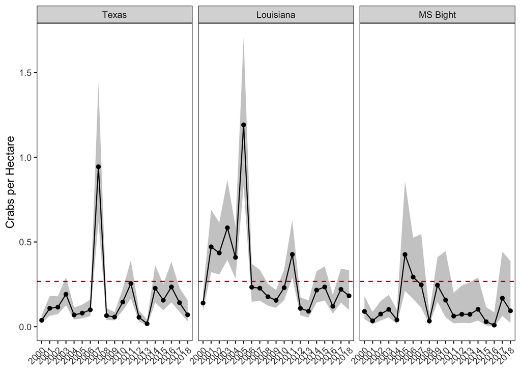

### Observed vs. Predicted

Model prediction (black) & observed mean values (blue)

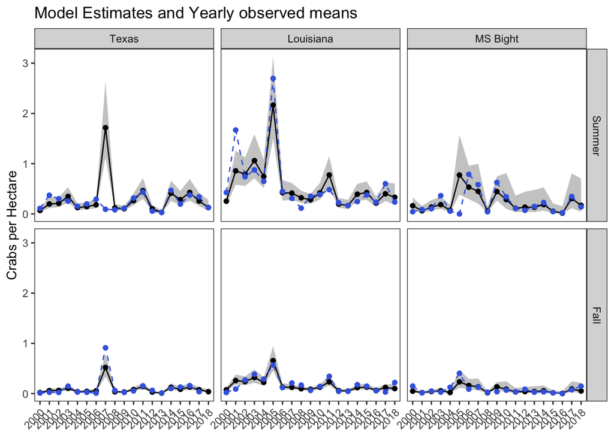

## Model B. 2009-2018

Model is a generalized linear model with a negative binomial error distribution. Blue crab catch is predicted as the sum of linear predictors for the year and season when the station was sampled in addition to the region in which it took place, with an interaction between survey year and region. An offset of area towed in hectares was used to predict catch as a rate and account for differences in sampling effort at different stations.

### Interaction Plot

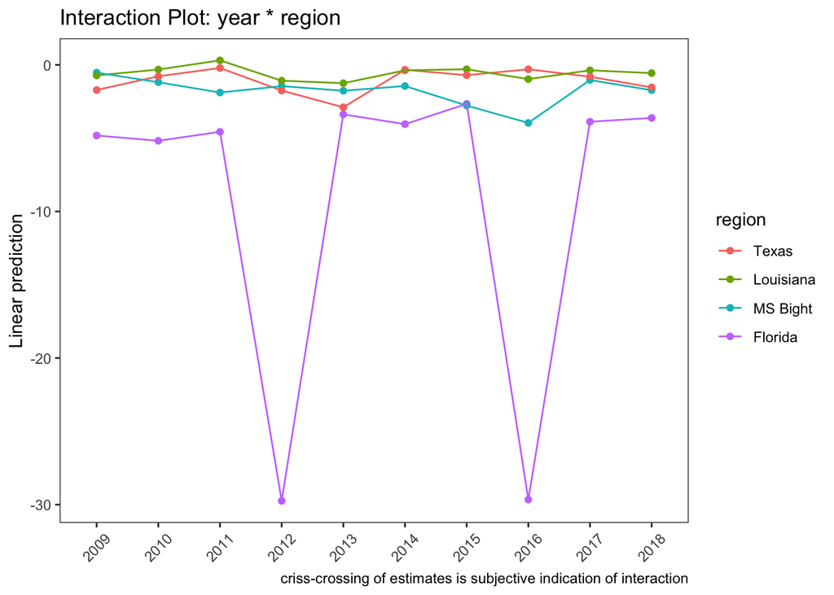

### Model Summary

| term | estimate | std.error | statistic | p.value | signif. |
| --- | --- | --- | --- | --- | --- |
| (Intercept) | -2.2365366 | 2.067740e-01 | -10.8163341 | 0.0000000 | * |
| year_f2010 | 0.9327593 | 2.919770e-01 | 3.1946332 | 0.0014001 | * |
| year_f2011 | 1.5017278 | 2.908812e-01 | 5.1626849 | 0.0000002 | * |
| year_f2012 | -0.0360237 | 3.428666e-01 | -0.1050662 | 0.9163233 |  |
| year_f2013 | -1.1799056 | 4.695853e-01 | -2.5126542 | 0.0119827 | * |
| year_f2014 | 1.3797400 | 3.047361e-01 | 4.5276558 | 0.0000060 | * |
| year_f2015 | 1.0094688 | 3.072697e-01 | 3.2852861 | 0.0010188 | * |
| year_f2016 | 1.4121864 | 3.117953e-01 | 4.5292099 | 0.0000059 | * |
| year_f2017 | 0.9054476 | 3.109851e-01 | 2.9115463 | 0.0035964 | * |
| year_f2018 | 0.1784394 | 4.367306e-01 | 0.4085800 | 0.6828479 |  |
| regionLouisiana | 0.9938844 | 2.604943e-01 | 3.8153789 | 0.0001360 | * |
| regionMS Bight | 1.1850534 | 3.016999e-01 | 3.9279207 | 0.0000857 | * |
| regionFlorida | -3.1051374 | 6.390040e-01 | -4.8593399 | 0.0000012 | * |
| seasonFall | -1.2678351 | 9.489630e-02 | -13.3602144 | 0.0000000 | * |
| year_f2010:regionLouisiana | -0.5304500 | 3.819282e-01 | -1.3888736 | 0.1648712 |  |
| year_f2011:regionLouisiana | -0.4733305 | 3.815818e-01 | -1.2404432 | 0.2148115 |  |
| year_f2012:regionLouisiana | -0.3245976 | 4.431647e-01 | -0.7324536 | 0.4638917 |  |
| year_f2013:regionLouisiana | 0.6498545 | 5.586839e-01 | 1.1631880 | 0.2447532 |  |
| year_f2014:regionLouisiana | -1.0345131 | 3.996120e-01 | -2.5887935 | 0.0096313 | * |
| year_f2015:regionLouisiana | -0.5877309 | 4.012382e-01 | -1.4647932 | 0.1429774 |  |
| year_f2016:regionLouisiana | -1.6644446 | 4.127629e-01 | -4.0324475 | 0.0000552 | * |
| year_f2017:regionLouisiana | -0.5567964 | 4.100412e-01 | -1.3579035 | 0.1744943 |  |
| year_f2018:regionLouisiana | -0.0201145 | 5.488016e-01 | -0.0366517 | 0.9707628 |  |
| year_f2010:regionMS Bight | -1.5893384 | 5.405180e-01 | -2.9403987 | 0.0032779 | * |
| year_f2011:regionMS Bight | -2.8589086 | 6.214104e-01 | -4.6006775 | 0.0000042 | * |
| year_f2012:regionMS Bight | -0.8863818 | 6.369183e-01 | -1.3916726 | 0.1640216 |  |
| year_f2013:regionMS Bight | -0.0560339 | 7.511082e-01 | -0.0746016 | 0.9405317 |  |
| year_f2014:regionMS Bight | -2.2954727 | 5.915182e-01 | -3.8806457 | 0.0001042 | * |
| year_f2015:regionMS Bight | -3.2553797 | 7.383571e-01 | -4.4089504 | 0.0000104 | * |
| year_f2016:regionMS Bight | -4.8430972 | 1.143874e+00 | -4.2339435 | 0.0000230 | * |
| year_f2017:regionMS Bight | -1.4097640 | 5.574585e-01 | -2.5289129 | 0.0114416 | * |
| year_f2018:regionMS Bight | -1.3784774 | 7.625142e-01 | -1.8078056 | 0.0706368 |  |
| year_f2010:regionFlorida | -1.2931811 | 9.800153e-01 | -1.3195519 | 0.1869847 |  |
| year_f2011:regionFlorida | -1.2502857 | 9.088825e-01 | -1.3756297 | 0.1689363 |  |
| year_f2012:regionFlorida | -24.8886629 | 8.605019e+04 | -0.0002892 | 0.9997692 |  |
| year_f2013:regionFlorida | 2.6234020 | 8.394040e-01 | 3.1253150 | 0.0017761 | * |
| year_f2014:regionFlorida | -0.6072040 | 7.811682e-01 | -0.7773025 | 0.4369803 |  |
| year_f2015:regionFlorida | 1.1462852 | 7.169613e-01 | 1.5988103 | 0.1098628 |  |
| year_f2016:regionFlorida | -26.2510380 | 9.093251e+04 | -0.0002887 | 0.9997697 |  |
| year_f2017:regionFlorida | 0.0346248 | 7.968898e-01 | 0.0434499 | 0.9653429 |  |
| year_f2018:regionFlorida | 1.0195593 | 8.329089e-01 | 1.2240947 | 0.2209165 |  |

### Deviance

| null.deviance | df.null | logLik | AIC | BIC | deviance | df.residual |
| --- | --- | --- | --- | --- | --- | --- |
| 3412.127 | 6230 | -3424.967 | 6933.935 | 7216.901 | 2183.195 | 6190 |

Goodness of fit for generalized linear models is described using deviance. A glm will report 2 deviance measures:

`null.deviance` is the residual variation remaining from the null model. The null model here is the grand mean of blue crab catch per hectare of all observations

`deviance` is the residual variation remaining from the fitted model. Numbers closer to the null.deviance indicate that the model did not perform much better than the null model.

`% deviance explained` is calculated as $\frac{null.deviance - deviance}{null.deviance} * 100$ and expresses the improvement of the fitted model over the null in % deviance explained.

**Percent Deviance for model B.** = 0.3601659

### Likelihood Ratio Test

| Predictor | Df | Deviance | AIC | LRT | Pr(>Chi) |
| --- | --- | --- | --- | --- | --- |
|  | NA | 2183.195 | 6931.935 | NA | NA |
| year_f | 9 | 2261.870 | 6992.609 | 78.67436 | 0 |
| region | 3 | 2295.875 | 7038.615 | 112.68032 | 0 |
| year_f:region | 27 | 2327.365 | 7022.105 | 144.17031 | 0 |

### CPUE Timeline

Because we used area towed in the model as an offset predictions from our model can be interprated as crabs per hectare.

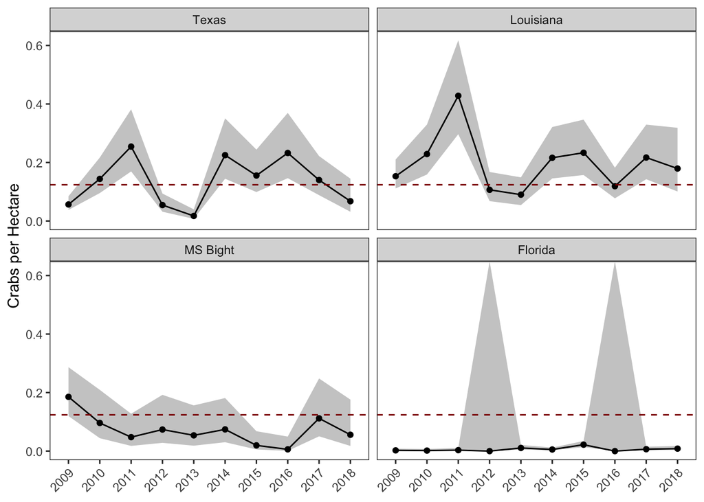

### Observed vs. Predicted

Model prediction (black) & observed mean values (blue)

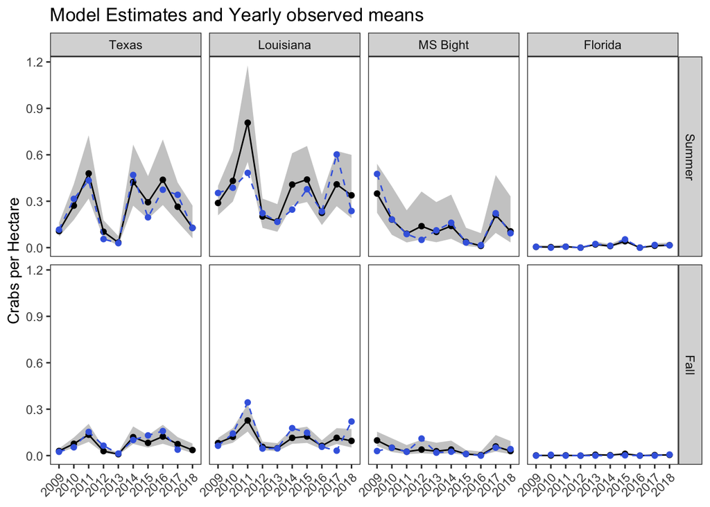

# Manuscript Model

## Model Dataset

- Total Number of Stations = 7669
- Starting in 2000 and continuing through 2018
- Total Sapidus Caught was 5430
- Overall Frequency of Occurrence was 21.3717564
- Overall Mean Catch Crabs/Hectare:** 0.267
- Stations with no catch:** 6030 / 7669 Stations **or** 78.63%

## Yearly Catch Plot

*NOTE: Zeros removed for plotting*

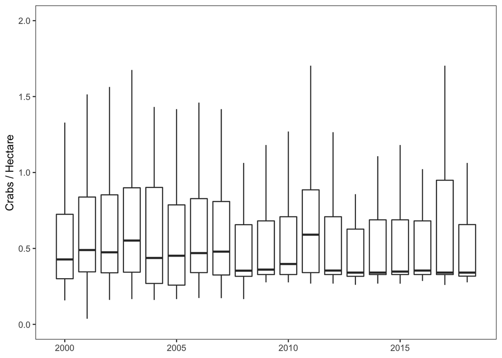

## Region - Season Plot

*NOTE: Zeros removed for plotting*

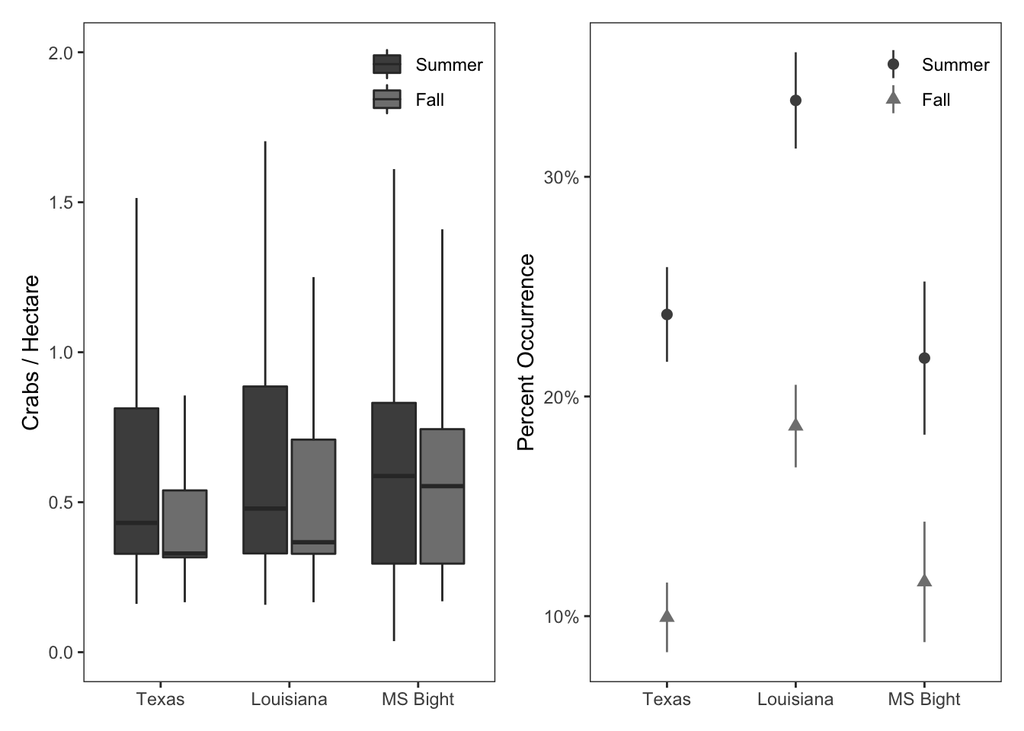

## Candidate Models

| Formulation | AIC | Delta AIC |
| --- | --- | --- |
| no interactions | 13649.41 | 143.030608 |
| year * region | 13506.38 | 0.000000 |
| year * season | 13547.85 | 41.477763 |
| region * season | 13650.10 | 143.728943 |
| all interactions | 13510.21 | 3.830144 |